# Getting Started with Rmarkdown

#### Autor

- Sergio García Prado - garciparedes.me

#### Fecha

- Mayo de 2018

## Descripción

En este trabajo se van a realizar distintos gráficos mediante la implementación del paquete base *graphics* y en algunos casos el paquete *lattice*. Los diagramas que se van a generar se refieren a funciones de densidad y distribución para la distribución gaussiana ajustada sobre distintos parámetros.

Dichos gráficos han sido generados siguiendo un ejercicio de la asignatura *Computación Estadística* del grado en *Estadística* de la Universidad de Valladolid. En concreto, se ha realizado el **Ejercicio 3 de la Hoja 5**

Este documento se ha realizado apoyandose en el lenguaje **R** junto con los paquetes *rmarkdown* (para la generación del documento) y *lattice* (para la generación avanzada de gráficos).

```r
rm(list = ls())
```

```r
library(lattice)
```

### Apartado a

El enunciado del apartado es el siguiente:

*Realizar en una ventana dividida en dos filas y cuatro columnas la representación la función de densidad y la función de distribución (una en la primera fila y otra en la segunda) de las siguientes distribuciones normales: N(0,1), N(2, 1), N(0,0.25) N(2, 0.25). Nota: utilizar la misma escala en los ejes x e y para las cuatro distribuciones.*

```r
means <- c(0, 2)
deviations <- c(1, 0.25)
limits <- c(-6, 6)
x <- seq(limits[1], limits[2], length = 200)
```

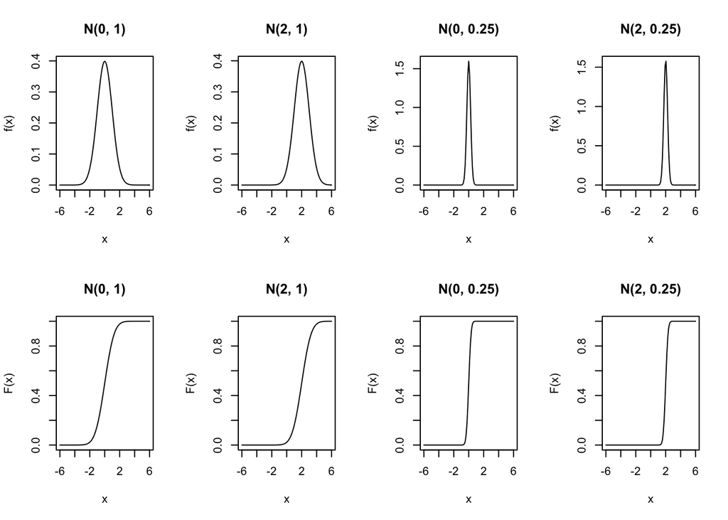

```r
par(mfrow = c(2, 4))
for (s in deviations) {
  for (m in means) {
    curve(dnorm(x, m, s), from = limits[1], to = limits[2], ylab = "f(x)",
         main = paste0("N(",m, ", ", s, ")"))
  }
}
for (s in deviations) {
  for (m in means) {
    curve(pnorm(x, m, s), from = limits[1], to = limits[2], ylab = "F(x)",
         main = paste0("N(",m, ", ", s, ")"))
  }
}
```

### Apartado b

El enunciado del apartado es el siguiente:

*Realizar los gráficos anteriores en una ventana dividida en dos, en una poner las cuatro funciones de densidad y en otra las cuatro funciones de distribución.*

```r
par(mfrow = c(1, 1))
```

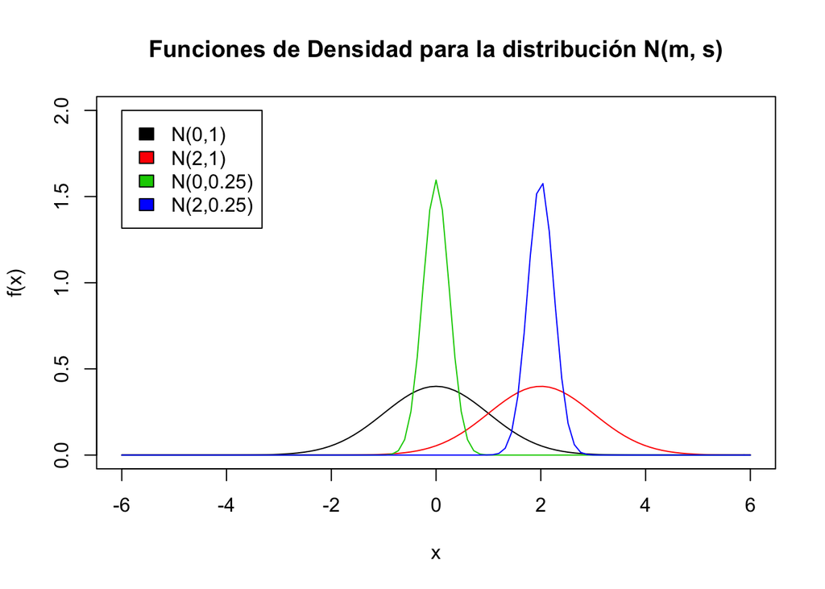

```r
plot(limits, c(0, 2), type = "n", ylab = "f(x)", xlab = "x",
     main = "Funciones de Densidad para la distribución N(m, s)")
i <- 0
for (s in deviations) {
  for (m in means) {
    i <- i + 1
    curve(dnorm(x, m, s), from = limits[1], to = limits[2] , col = i, add = TRUE)
  }
}
legend(limits[1], 2, paste0("N(", rep(means, length.out = i),
                            "," , rep(deviations, each = length(means)),")"),
       fill = 1:i)
```

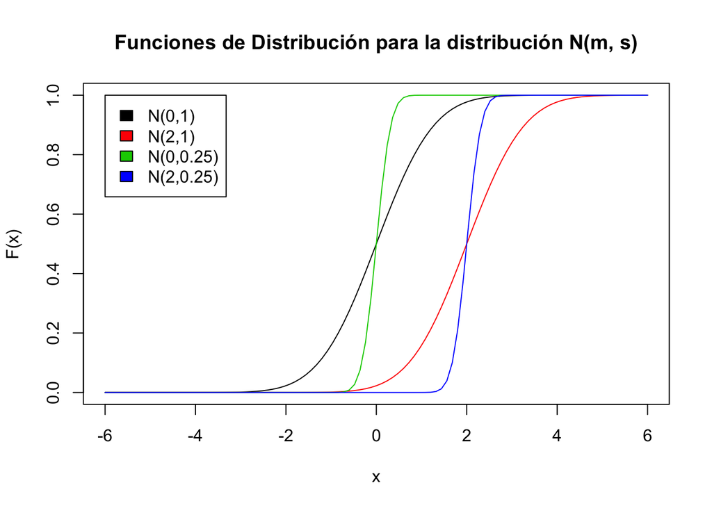

```r
plot(limits, c(0, 1), type = "n", ylab = "F(x)", xlab = "x",
     main = "Funciones de Distribución para la distribución N(m, s)")
i <- 0
for (s in deviations) {
  for (m in means) {
    i <- i + 1
    curve(pnorm(x, m, s), from = limits[1], to = limits[2] , col = i, add = TRUE)
  }
}
legend(limits[1], 1, paste0("N(", rep(means, length.out = i),
                            "," , rep(deviations, each = length(means)),")"),
       fill = 1:i)
```

### Apartado c

El enunciado del apartado es el siguiente:

*Generar 400 datos de la distribución normal de media 3 y varianza 4. Obtener su media, mediana, varianza, mínimo, máximo, cuartiles y recorrido intercuartílico. Comparar la media, mediana y varianza muestrales con los parámetros correspondientes de la distribución original.*

```r
m <- 3
s <- 2
d <- rnorm(400, m, s)
```

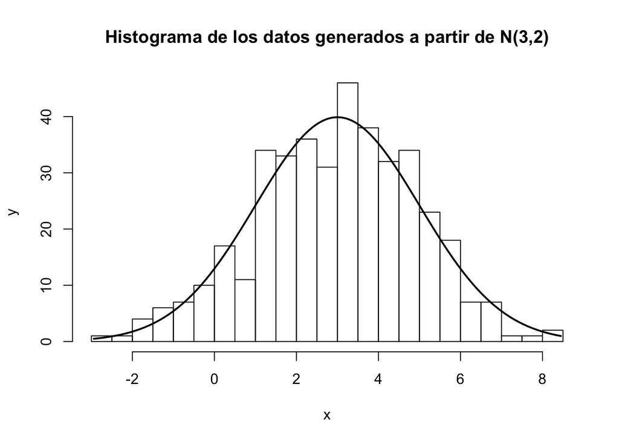

```r
h <- hist(d, breaks = 30, xlab="x", ylab ="y",
    main = paste0("Histograma de los datos generados a partir de N(",
                  m , ",", s, ")"))
curve(dnorm(x, mean = m, sd = s) * diff(h$mids[1:2]) * length(d),
      from = min(d), to = max(d), lwd = 2, add = TRUE)
```

#### Paquete *lattice*

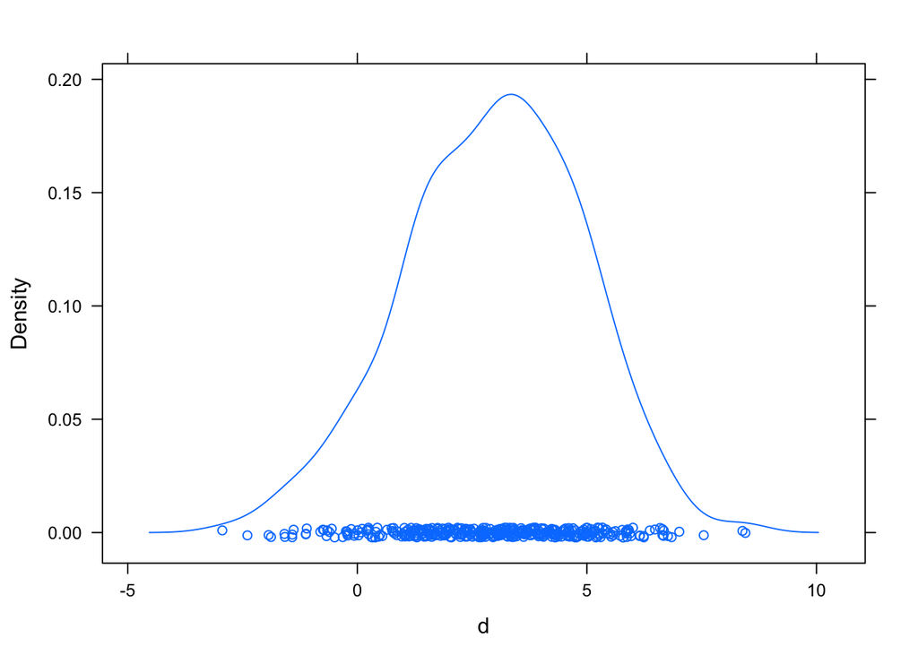

```r
densityplot(d)
```

#### Generación de Estadísticos

```r
(params <- list(mean = mean(d), median = median(d), var = var(d),
               min = min(d), max = max(d), iqr = IQR(d),
               q.15 = quantile(d, 0.25), q.75 = quantile(d, 0.75)))
```

```
## $mean
## [1] 2.965385
##
## $median
## [1] 3.100009
##
## $var
## [1] 3.803826
##
## $min
## [1] -2.941658
##
## $max
## [1] 8.451458
##
## $iqr
## [1] 2.712269
##
## $q.15
##      25%
## 1.617904
##
## $q.75
##      75%
## 4.330173
```

La media se encuentra próxima a su valor teórico

```r
abs(params$mean - 3)
```

```
## [1] 0.03461488
```

La mediana se encuentra próxima a su valor teórico

```r
abs(params$median - 3)
```

```
## [1] 0.1000089
```

La varianza se encuentra próxima a su valor teórico

```r
abs(params$var - 4)
```

```
## [1] 0.1961739
```